# Introduction to R formulas

Nicolas Delhomme

2021-05-17

# 1 Formulas

## 1.1 What are formulas?

A lot of material (more than) inspired from a [DataCamp tutorial](https://www.datacamp.com/community/tutorials/r-formula-tutorial)

```r
?formula
```

It is a quoted, *i.e.* non evaluated expression:

```r
x <- 1
x * 10
```

```
## [1] 10
```

```r
quote(x * 10)
```

```
## x * 10
```

```r
typeof(quote(x * 10))
```

```
## [1] "language"
```

```r
class(quote(x * 10))
```

```
## [1] "call"
```

```r
eval(quote(x * 10))
```

```
## [1] 10
```

An example: `Sepal.Width ~ Petal.Width + log(Petal.Length) + Species`

## 1.2 Response(s) and predictor(s)

In the example above, we model the sepal width as a function of the petal width and length and the species. Formulas can be one or two sided:

One sided:

```r
e <- ~ x + y + z
```

Two sided

```r
f <- y ~ x + b
```

In a comparison

```r
length(e)
```

```
## [1] 2
```

```r
length(f)
```

```
## [1] 3
```

```r
e[[1]]
```

```
## `~`
```

```r
e[[2]]
```

```
## x + y + z
```

```r
f[[3]]
```

```
## x + b
```

What is stored in a formula?

```r
all.vars(f)
```

```
## [1] "y" "x" "b"
```

```r
all.vars(e)
```

```
## [1] "x" "y" "z"
```

```r
terms(f)
```

```
## y ~ x + b
## attr(,"variables")
## list(y, x, b)
## attr(,"factors")
##   x b
## y 0 0
## x 1 0
## b 0 1
## attr(,"term.labels")
## [1] "x" "b"
## attr(,"order")
## [1] 1 1
## attr(,"intercept")
## [1] 1
## attr(,"response")
## [1] 1
## attr(,".Environment")
## <environment: R_GlobalEnv>
```

```r
terms(e)
```

```
## ~x + y + z
## attr(,"variables")
## list(x, y, z)
## attr(,"factors")
##   x y z
## x 1 0 0
## y 0 1 0
## z 0 0 1
## attr(,"term.labels")
## [1] "x" "y" "z"
## attr(,"order")
## [1] 1 1 1
## attr(,"intercept")
## [1] 1
## attr(,"response")
## [1] 0
## attr(,".Environment")
## <environment: R_GlobalEnv>
```

## 1.3 Writing formulas

### 1.3.1 In plain

```r
y ~ x
```

```
## y ~ x
```

```r
~ x + y + z
```

```
## ~x + y + z
```

```r
g <- y ~ x + b
```

### 1.3.2 Programmatically

```r
"y ~ x1 + x2"
```

```
## [1] "y ~ x1 + x2"
```

```r
h <- as.formula("y ~ x1 + x2")
h <- formula("y ~ x1 + x2")
as.formula(paste(c("~ x","y","z"),collapse="+"))
```

```
## ~x + y + z
```

## 1.4 Formula operators

```r
y ~ x1 + x2
```

```
## y ~ x1 + x2
```

Remove predictors

```r
y ~ x1 - x2
```

```
## y ~ x1 - x2
```

### 1.4.1 *, :, %in% and ^

Important for regression, essential to describe interaction terms

Note that these are the same:

```r
y ~ x1 * x2
```

```
## y ~ x1 * x2
```

```r
y ~ x1 + x2 + x1:x2
```

```
## y ~ x1 + x2 + x1:x2
```

Demonstration:

```r
x = rnorm(5)
x2 = rnorm(5)
y = rnorm(5)

model.frame(y ~ x * x2, data = data.frame(x = x, y = y, x2=x2))
```

```
##            y          x         x2
## 1  1.0459139  0.4529434 -2.1455726
## 2  0.4513412  1.0048967 -0.7108345
## 3 -1.2337187 -0.7672477 -2.0449303
## 4 -0.4304559  1.3203156  1.1574007
## 5  2.5382484 -0.2498577 -0.7576184
```

```r
model.frame(y ~ x + x2 + x:x2 , data = data.frame(x = x, y = y, x2=x2))
```

```
##            y          x         x2
## 1  1.0459139  0.4529434 -2.1455726
## 2  0.4513412  1.0048967 -0.7108345
## 3 -1.2337187 -0.7672477 -2.0449303
## 4 -0.4304559  1.3203156  1.1574007
## 5  2.5382484 -0.2498577 -0.7576184
```

```r
terms(y ~ x1 * x2)
```

```
## y ~ x1 * x2
## attr(,"variables")
## list(y, x1, x2)
## attr(,"factors")
##    x1 x2 x1:x2
## y   0  0     0
## x1  1  0     1
## x2  0  1     1
## attr(,"term.labels")
## [1] "x1"    "x2"    "x1:x2"
## attr(,"order")
## [1] 1 1 2
## attr(,"intercept")
## [1] 1
## attr(,"response")
## [1] 1
## attr(,".Environment")
## <environment: R_GlobalEnv>
```

```r
terms(y ~ x1 + x2 + x1:x2)
```

```
## y ~ x1 + x2 + x1:x2
## attr(,"variables")
## list(y, x1, x2)
## attr(,"factors")
##    x1 x2 x1:x2
## y   0  0     0
## x1  1  0     1
## x2  0  1     1
## attr(,"term.labels")
## [1] "x1"    "x2"    "x1:x2"
## attr(,"order")
## [1] 1 1 2
## attr(,"intercept")
## [1] 1
## attr(,"response")
## [1] 1
## attr(,".Environment")
## <environment: R_GlobalEnv>
```

Nesting:

The terms on the left are nested within those on the right. A simple example to revisit the example above

```r
terms(y ~ x1 + x2 + x2 %in% x1)
```

```
## y ~ x1 + x2 + x2 %in% x1
## attr(,"variables")
## list(y, x1, x2)
## attr(,"factors")
##    x1 x2 x1:x2
## y   0  0     0
## x1  1  0     1
## x2  0  1     1
## attr(,"term.labels")
## [1] "x1"    "x2"    "x1:x2"
## attr(,"order")
## [1] 1 1 2
## attr(,"intercept")
## [1] 1
## attr(,"response")
## [1] 1
## attr(,".Environment")
## <environment: R_GlobalEnv>
```

```r
terms(y~x2 %in% x1)
```

```
## y ~ x2 %in% x1
## attr(,"variables")
## list(y, x2, x1)
## attr(,"factors")
##    x2:x1
## y      0
## x2     2
## x1     2
## attr(,"term.labels")
## [1] "x2:x1"
## attr(,"order")
## [1] 2
## attr(,"intercept")
## [1] 1
## attr(,"response")
## [1] 1
## attr(,".Environment")
## <environment: R_GlobalEnv>
```

Crossing to a specified degree:

```r
terms(y ~ (a+b+c)^2)
```

```
## y ~ (a + b + c)^2
## attr(,"variables")
## list(y, a, b, c)
## attr(,"factors")
##   a b c a:b a:c b:c
## y 0 0 0   0   0   0
## a 1 0 0   1   1   0
## b 0 1 0   1   0   1
## c 0 0 1   0   1   1
## attr(,"term.labels")
## [1] "a"   "b"   "c"   "a:b" "a:c" "b:c"
## attr(,"order")
## [1] 1 1 1 2 2 2
## attr(,"intercept")
## [1] 1
## attr(,"response")
## [1] 1
## attr(,".Environment")
## <environment: R_GlobalEnv>
```

```r
terms(y ~ (a+b+c) * (a+b+c))
```

```
## y ~ (a + b + c) * (a + b + c)
## attr(,"variables")
## list(y, a, b, c)
## attr(,"factors")
##   a b c a:b a:c b:c
## y 0 0 0   0   0   0
## a 1 0 0   1   1   0
## b 0 1 0   1   0   1
## c 0 0 1   0   1   1
## attr(,"term.labels")
## [1] "a"   "b"   "c"   "a:b" "a:c" "b:c"
## attr(,"order")
## [1] 1 1 1 2 2 2
## attr(,"intercept")
## [1] 1
## attr(,"response")
## [1] 1
## attr(,".Environment")
## <environment: R_GlobalEnv>
```

```r
terms(y ~ a*b*c - a:b:c)
```

```
## y ~ a * b * c - a:b:c
## attr(,"variables")
## list(y, a, b, c)
## attr(,"factors")
##   a b c a:b a:c b:c
## y 0 0 0   0   0   0
## a 1 0 0   1   1   0
## b 0 1 0   1   0   1
## c 0 0 1   0   1   1
## attr(,"term.labels")
## [1] "a"   "b"   "c"   "a:b" "a:c" "b:c"
## attr(,"order")
## [1] 1 1 1 2 2 2
## attr(,"intercept")
## [1] 1
## attr(,"response")
## [1] 1
## attr(,".Environment")
## <environment: R_GlobalEnv>
```

### 1.4.2 conditionals:

For example

```r
Sepal.Width ~ Petal.Width | Species
```

```
## Sepal.Width ~ Petal.Width | Species
```

but be careful, it’s not base R and has different meaning in different packages

```r
terms(Sepal.Width ~ Petal.Width | Species)
```

```
## Sepal.Width ~ Petal.Width | Species
## attr(,"variables")
## list(Sepal.Width, Petal.Width | Species)
## attr(,"factors")
##                       Petal.Width | Species
## Sepal.Width                               0
## Petal.Width | Species                     1
## attr(,"term.labels")
## [1] "Petal.Width | Species"
## attr(,"order")
## [1] 1
## attr(,"intercept")
## [1] 1
## attr(,"response")
## [1] 1
## attr(,".Environment")
## <environment: R_GlobalEnv>
```

## 1.5 Caveats

Formulas usually just involve variables and factor names, they can also use arithmetic expressions. Imagine we want a model with x and x^2, writing the following fails:

```r
terms(y ~ x + x^2)
```

```
## y ~ x + x^2
## attr(,"variables")
## list(y, x)
## attr(,"factors")
##   x
## y 0
## x 1
## attr(,"term.labels")
## [1] "x"
## attr(,"order")
## [1] 1
## attr(,"intercept")
## [1] 1
## attr(,"response")
## [1] 1
## attr(,".Environment")
## <environment: R_GlobalEnv>
```

Why? Because of the above where ^2 is crossing x to the second degree (and we have only one variable)

```r
terms(y ~ x + x * x)
```

```
## y ~ x + x * x
## attr(,"variables")
## list(y, x)
## attr(,"factors")
##   x
## y 0
## x 1
## attr(,"term.labels")
## [1] "x"
## attr(,"order")
## [1] 1
## attr(,"intercept")
## [1] 1
## attr(,"response")
## [1] 1
## attr(,".Environment")
## <environment: R_GlobalEnv>
```

Rather we need to encapsulate arithmetic operations in `I()`, the *as-is* operator

```r
terms(y ~ x + I(x^2))
```

```
## y ~ x + I(x^2)
## attr(,"variables")
## list(y, x, I(x^2))
## attr(,"factors")
##        x I(x^2)
## y      0      0
## x      1      0
## I(x^2) 0      1
## attr(,"term.labels")
## [1] "x"      "I(x^2)"
## attr(,"order")
## [1] 1 1
## attr(,"intercept")
## [1] 1
## attr(,"response")
## [1] 1
## attr(,".Environment")
## <environment: R_GlobalEnv>
```

```r
terms(y ~ I(3 * x))
```

```
## y ~ I(3 * x)
## attr(,"variables")
## list(y, I(3 * x))
## attr(,"factors")
##          I(3 * x)
## y               0
## I(3 * x)        1
## attr(,"term.labels")
## [1] "I(3 * x)"
## attr(,"order")
## [1] 1
## attr(,"intercept")
## [1] 1
## attr(,"response")
## [1] 1
## attr(,".Environment")
## <environment: R_GlobalEnv>
```

## 1.6 Inspecting formulas

Well, we have repeatedly used `terms`. There is also `all.vars`. And we toy’ed with `model.frame`.

## 1.7 Modifying formulas

For example, we could `update` our `f` formula from above

```r
f
```

```
## y ~ x + b
```

Here, `~.` is a special variable that represent the formula in `f`

```r
update(f,~. -b)
```

```
## y ~ x
```

Arguably, one will most often simply rewrite the formula, using *e.g.* paste, but being able to dynamically update a model can come in handy

```r
reformulate(termlabels=all.vars(e),intercept = FALSE,response="w")
```

```
## w ~ x + y + z - 1
```

## 1.8 Application

Formulas can be used for more than just modeling. For example, the `ggformula` and `lattice` graphic package use them. They also relies on the *non-standard evaluation (NSE)*. The NSE means that part of the formula will be evaluated only at run time. For example:

```r
subset(iris, Sepal.Width > 3)
```

```
##     Sepal.Length Sepal.Width Petal.Length Petal.Width    Species
## 1            5.1         3.5          1.4         0.2     setosa
## 3            4.7         3.2          1.3         0.2     setosa
## 4            4.6         3.1          1.5         0.2     setosa
## 5            5.0         3.6          1.4         0.2     setosa
## 6            5.4         3.9          1.7         0.4     setosa
## 7            4.6         3.4          1.4         0.3     setosa
## 8            5.0         3.4          1.5         0.2     setosa
## 10           4.9         3.1          1.5         0.1     setosa
## 11           5.4         3.7          1.5         0.2     setosa
## 12           4.8         3.4          1.6         0.2     setosa
## 15           5.8         4.0          1.2         0.2     setosa
## 16           5.7         4.4          1.5         0.4     setosa
## 17           5.4         3.9          1.3         0.4     setosa
## 18           5.1         3.5          1.4         0.3     setosa
```

[output cut: 53 more lines]

```r
tryCatch(iris[Sepal.Width > 3,],error=function(e){e})
```

```
## <simpleError in `[.data.frame`(iris, Sepal.Width > 3, ): object 'Sepal.Width' not found>
```

```r
attach(iris)
iris[Sepal.Width > 3,]
```

```
##     Sepal.Length Sepal.Width Petal.Length Petal.Width    Species
## 1            5.1         3.5          1.4         0.2     setosa
## 3            4.7         3.2          1.3         0.2     setosa
## 4            4.6         3.1          1.5         0.2     setosa
## 5            5.0         3.6          1.4         0.2     setosa
## 6            5.4         3.9          1.7         0.4     setosa
## 7            4.6         3.4          1.4         0.3     setosa
## 8            5.0         3.4          1.5         0.2     setosa
## 10           4.9         3.1          1.5         0.1     setosa
## 11           5.4         3.7          1.5         0.2     setosa
## 12           4.8         3.4          1.6         0.2     setosa
## 15           5.8         4.0          1.2         0.2     setosa
## 16           5.7         4.4          1.5         0.4     setosa
## 17           5.4         3.9          1.3         0.4     setosa
## 18           5.1         3.5          1.4         0.3     setosa
```

[output cut: 53 more lines]

```r
detach(iris)
```

NSE is used in many packages (and so are formulas) for dynamic programming.

Examples:

- [Brodie Gaslam blog](https://www.brodieg.com/2020/05/05/on-nse/)
- [Hadley Wickham Advanced R](http://adv-r.had.co.nz/Computing-on-the-language.html)

but modeling is, if not anymore the sole, the original application.

### 1.8.1 linear models

```r
lm.m <- lm(Sepal.Width ~ Petal.Width + log(Petal.Length) + Species,
           data = iris,
           subset = Sepal.Length > 4.6)


print(lm.m)
```

```
##
## Call:
## lm(formula = Sepal.Width ~ Petal.Width + log(Petal.Length) +
##     Species, data = iris, subset = Sepal.Length > 4.6)
##
## Coefficients:
##       (Intercept)        Petal.Width  log(Petal.Length)  Speciesversicolor
##            3.1531             0.6620             0.4612            -1.9265
##  Speciesvirginica
##           -2.3088
```

```r
summary(lm.m)
```

```
##
## Call:
## lm(formula = Sepal.Width ~ Petal.Width + log(Petal.Length) +
##     Species, data = iris, subset = Sepal.Length > 4.6)
##
## Residuals:
##      Min       1Q   Median       3Q      Max
## -0.71339 -0.16347  0.01515  0.16655  0.79505
##
## Coefficients:
##                   Estimate Std. Error t value Pr(>|t|)
## (Intercept)         3.1531     0.1007  31.298  < 2e-16 ***
## Petal.Width         0.6620     0.1281   5.168 8.27e-07 ***
## log(Petal.Length)   0.4612     0.2541   1.815   0.0717 .
## Speciesversicolor  -1.9265     0.2423  -7.951 6.37e-13 ***
## Speciesvirginica   -2.3088     0.3087  -7.478 8.37e-12 ***
## ---
## Signif. codes:  0 '***' 0.001 '**' 0.01 '*' 0.05 '.' 0.1 ' ' 1
##
## Residual standard error: 0.2801 on 136 degrees of freedom
## Multiple R-squared:  0.6084, Adjusted R-squared:  0.5969
## F-statistic: 52.82 on 4 and 136 DF,  p-value: < 2.2e-16
```

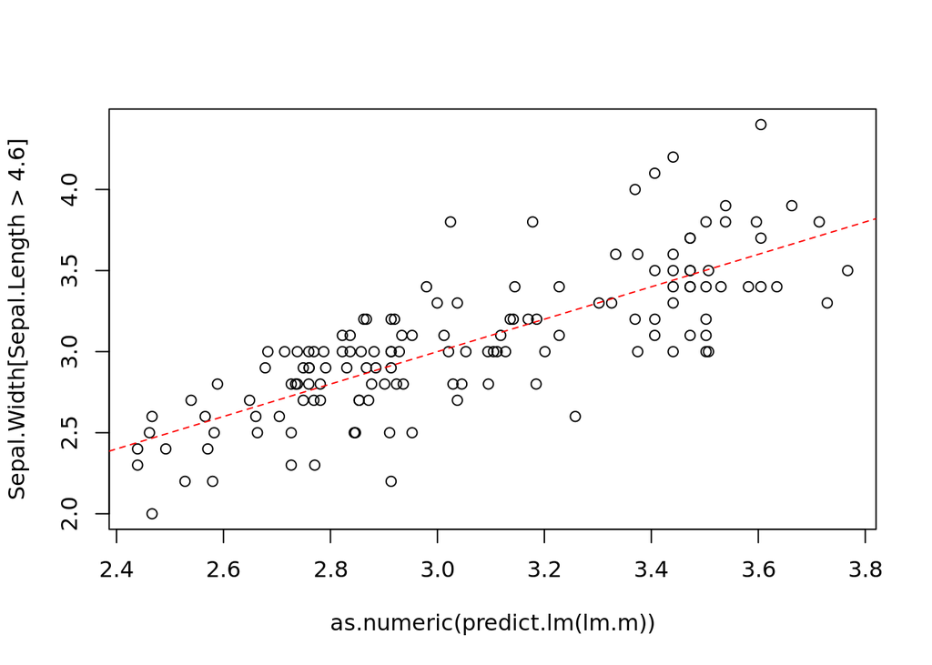

```r
attach(iris)

plot(as.numeric(predict.lm(lm.m)),Sepal.Width[Sepal.Length>4.6])

abline(0,1,lty=2,col="red")
```

```r
residuals.lm(lm.m)
```

```
##            1            2            3            5            6            8
##  0.059276497 -0.440723503 -0.206545664  0.159276497  0.237326870 -0.072542310
##           10           11           12           13           15           16
## -0.306338881  0.227457690 -0.102306816 -0.374520074  0.630369215  0.795050832
##           17           18           19           20           21           22
##  0.361047479 -0.006926932  0.203530299  0.261254261 -0.130266272  0.095050832
##           24           25           26           27           28           29
## -0.428876559 -0.181562398 -0.502306816 -0.234713674  0.027457690 -0.040723503
##           30           31           32           33           34           35
## -0.302306816 -0.402306816 -0.204949168  0.693661119  0.759276497 -0.372542310
##           36           37           38           40           41           44
## -0.169630785  0.093454336  0.225479926 -0.072542310  0.027250907 -0.267120532
##           45           46           47           49           50           51
##  0.086030744 -0.506926932  0.297693184  0.227457690 -0.140723503  0.332754052
##           52           53           54           55           56           57
##  0.286605512  0.147331601 -0.426667298 -0.123530935  0.019012370  0.300347194
##           58           59           60           61           62           63
## -0.039337061  0.108875923 -0.081194413 -0.466473698  0.118424319 -0.328057012
##           64           65           66           67           68           69
##  0.032754052  0.221923894  0.263173192  0.086605512  0.160555008 -0.713394488
##           70           71           72           73           74           75
## -0.082584126  0.058230719  0.073332702 -0.452668399  0.065160910  0.139979152
##           76           77           78           79           80           81
##  0.163173192 -0.076955565 -0.094392539 -0.013394488  0.133526302 -0.170604497
##           82           83           84           85           86           87
## -0.092101946  0.051212445 -0.337321879  0.086605512  0.420402083  0.166550623
##           88           89           90           91           92           93
## -0.470623379  0.261944721 -0.226667298 -0.104419950  0.142672494 -0.060463869
##           94           95           96           97           98           99
## -0.139337061 -0.049168823  0.317034606  0.150831177  0.139979152  0.038415590
##          100          101          102          103          104          105
##  0.061944721 -0.025775598 -0.153602956 -0.053210611  0.069467211 -0.111530262
##          106          107          108          109          110          111
## -0.104917963 -0.163472136  0.015146879 -0.346716547  0.266601257  0.280193615
##          112          113          114          115          116          117
## -0.171343211 -0.020833125 -0.410673615 -0.384620101  0.063843073  0.177777162
##          118          119          120          121          122          123
##  0.621943293 -0.657825519 -0.379656471  0.030287203 -0.101356333 -0.245649850
##          124          125          126          127          128          129
## -0.068949476  0.262694060  0.337648404  0.040559929  0.231050524 -0.229143076
##          130          131          132          133          134          135
##  0.285690311 -0.136178170  0.775477040 -0.295346504  0.211210760  0.034280927
##          136          137          138          139          140          141
## -0.200991886  0.172246638  0.277777162  0.240559929  0.087629310 -0.127753362
##          142          143          144          145          146          147
## -0.018416672 -0.153602956  0.014382531 -0.002119655 -0.127372094 -0.344470187
##          148          149          150
##  0.071238193  0.255222452  0.212600473
```

```r
chisq.test(abs(residuals.lm(lm.m)))
```

```
##
##  Chi-squared test for given probabilities
##
## data:  abs(residuals.lm(lm.m))
## X-squared = 19.872, df = 140, p-value = 1
```

```r
cor.test(as.numeric(predict.lm(lm.m)),Sepal.Width[Sepal.Length>4.6])
```

```
##
##  Pearson's product-moment correlation
##
## data:  as.numeric(predict.lm(lm.m)) and Sepal.Width[Sepal.Length > 4.6]
## t = 14.695, df = 139, p-value < 2.2e-16
## alternative hypothesis: true correlation is not equal to 0
## 95 percent confidence interval:
##  0.7056732 0.8373378
## sample estimates:
##       cor
## 0.7799941
```

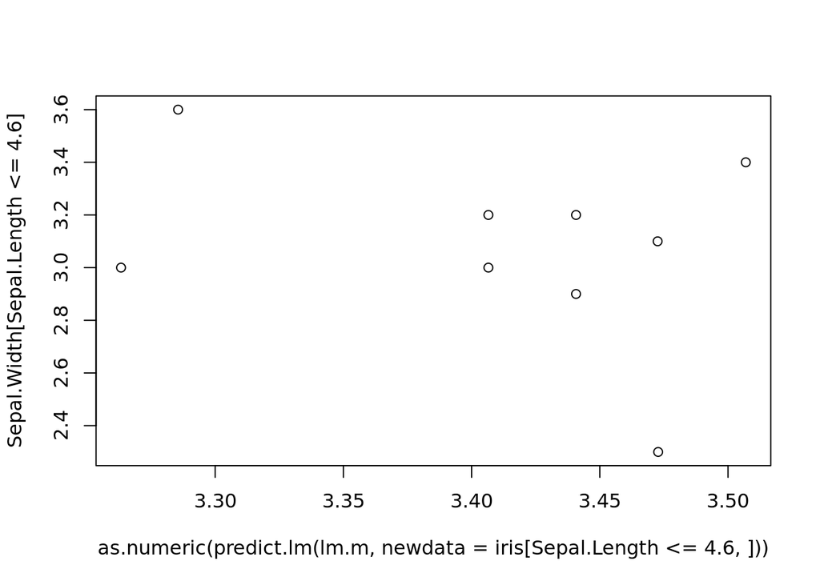

```r
plot(as.numeric(predict.lm(lm.m,newdata = iris[Sepal.Length<=4.6,])),
     Sepal.Width[Sepal.Length<=4.6])
```

```r
detach(iris)
```

```r
install.packages("nlme")
```

```r
library(nlme)
library(MASS)
data(oats)

names(oats) = c('block', 'variety', 'nitrogen', 'yield')
oats$mainplot = oats$variety
oats$subplot = oats$nitrogen

nlme.m = lme(yield ~ variety*nitrogen,
             random = ~ 1|block/mainplot,
             data = oats)

summary(nlme.m)
```

```
## Linear mixed-effects model fit by REML
##   Data: oats
##        AIC      BIC    logLik
##   559.0285 590.4437 -264.5143
##
## Random effects:
##  Formula: ~1 | block
##         (Intercept)
## StdDev:    14.64496
##
##  Formula: ~1 | mainplot %in% block
##         (Intercept) Residual
## StdDev:    10.29863 13.30727
##
## Fixed effects:  yield ~ variety * nitrogen
##                                     Value Std.Error DF   t-value p-value
## (Intercept)                      80.00000  9.106958 45  8.784492  0.0000
## varietyMarvellous                 6.66667  9.715028 10  0.686222  0.5082
## varietyVictory                   -8.50000  9.715028 10 -0.874933  0.4021
## nitrogen0.2cwt                   18.50000  7.682957 45  2.407927  0.0202
## nitrogen0.4cwt                   34.66667  7.682957 45  4.512152  0.0000
## nitrogen0.6cwt                   44.83333  7.682957 45  5.835427  0.0000
## varietyMarvellous:nitrogen0.2cwt  3.33333 10.865342 45  0.306786  0.7604
## varietyVictory:nitrogen0.2cwt    -0.33333 10.865342 45 -0.030679  0.9757
## varietyMarvellous:nitrogen0.4cwt -4.16667 10.865342 45 -0.383482  0.7032
## varietyVictory:nitrogen0.4cwt     4.66667 10.865342 45  0.429500  0.6696
## varietyMarvellous:nitrogen0.6cwt -4.66667 10.865342 45 -0.429500  0.6696
## varietyVictory:nitrogen0.6cwt     2.16667 10.865342 45  0.199411  0.8428
##  Correlation:
##                                  (Intr) vrtyMr vrtyVc ntr0.2 ntr0.4 ntr0.6
## varietyMarvellous                -0.533
## varietyVictory                   -0.533  0.500
## nitrogen0.2cwt                   -0.422  0.395  0.395
## nitrogen0.4cwt                   -0.422  0.395  0.395  0.500
## nitrogen0.6cwt                   -0.422  0.395  0.395  0.500  0.500
## varietyMarvellous:nitrogen0.2cwt  0.298 -0.559 -0.280 -0.707 -0.354 -0.354
## varietyVictory:nitrogen0.2cwt     0.298 -0.280 -0.559 -0.707 -0.354 -0.354
## varietyMarvellous:nitrogen0.4cwt  0.298 -0.559 -0.280 -0.354 -0.707 -0.354
## varietyVictory:nitrogen0.4cwt     0.298 -0.280 -0.559 -0.354 -0.707 -0.354
## varietyMarvellous:nitrogen0.6cwt  0.298 -0.559 -0.280 -0.354 -0.354 -0.707
## varietyVictory:nitrogen0.6cwt     0.298 -0.280 -0.559 -0.354 -0.354 -0.707
##                                  vM:0.2 vV:0.2 vM:0.4 vV:0.4 vM:0.6
## varietyMarvellous
## varietyVictory
## nitrogen0.2cwt
## nitrogen0.4cwt
## nitrogen0.6cwt
## varietyMarvellous:nitrogen0.2cwt
## varietyVictory:nitrogen0.2cwt     0.500
## varietyMarvellous:nitrogen0.4cwt  0.500  0.250
## varietyVictory:nitrogen0.4cwt     0.250  0.500  0.500
## varietyMarvellous:nitrogen0.6cwt  0.500  0.250  0.500  0.250
## varietyVictory:nitrogen0.6cwt     0.250  0.500  0.250  0.500  0.500
##
## Standardized Within-Group Residuals:
##         Min          Q1         Med          Q3         Max
## -1.81300898 -0.56144838  0.01758044  0.63864476  1.57034166
##
## Number of Observations: 72
## Number of Groups:
##               block mainplot %in% block
##                   6                  18
```

### 1.8.3 generalized linear models

```r
install.packages("MPDiR")
```

```r
library(MPDiR)

data(Chromatic)

glm.m <- glm(Thresh ~ Axis:(I(Age^-1) + Age),
             family = Gamma(link = "identity"),
             data = Chromatic)

summary(glm.m)
```

```
##
## Call:
## glm(formula = Thresh ~ Axis:(I(Age^-1) + Age), family = Gamma(link = "identity"),
##     data = Chromatic)
##
## Deviance Residuals:
##     Min       1Q   Median       3Q      Max
## -1.2160  -0.3728  -0.0805   0.2311   1.2932
##
## Coefficients:
##                       Estimate Std. Error t value Pr(>|t|)
## (Intercept)          3.282e-04  9.965e-05   3.294  0.00106 **
## AxisDeutan:I(Age^-1) 7.803e-03  3.686e-04  21.172  < 2e-16 ***
## AxisProtan:I(Age^-1) 8.271e-03  3.863e-04  21.410  < 2e-16 ***
## AxisTritan:I(Age^-1) 1.166e-02  5.284e-04  22.065  < 2e-16 ***
## AxisDeutan:Age       1.521e-05  3.418e-06   4.450 1.06e-05 ***
## AxisProtan:Age       1.540e-05  3.434e-06   4.484 9.10e-06 ***
## AxisTritan:Age       4.812e-05  5.838e-06   8.241 1.48e-15 ***
## ---
## Signif. codes:  0 '***' 0.001 '**' 0.01 '*' 0.05 '.' 0.1 ' ' 1
##
## (Dispersion parameter for Gamma family taken to be 0.2054848)
##
##     Null deviance: 543.35  on 510  degrees of freedom
## Residual deviance: 100.40  on 504  degrees of freedom
## AIC: -4777.6
##
## Number of Fisher Scoring iterations: 6
```

### 1.8.4 and more

see for example the `Formula` or `formula.tools` packages

```r
install.packages("Formula")
```

```r
library(Formula)
```

multi-response

```r
Formula(y1+y2~x1+x2)
```

```
## y1 + y2 ~ x1 + x2
```

multi-part

```r
Formula(y~x1|x2)
```

```
## y ~ x1 | x2
```

both

```r
Formula(y1+y2~x1+x2|I(x2^2))
```

```
## y1 + y2 ~ x1 + x2 | I(x2^2)
```

# 2 Further readings:

- Two opinion pieces by Max Kuhn (R Views blog): [Good](https://rviews.rstudio.com/2017/02/01/the-r-formula-method-the-good-parts/) and [Bad](https://rviews.rstudio.com/2017/03/01/the-r-formula-method-the-bad-parts/) parts about formulas